# Topic Modeling and a classification model for Reuters21578 Dataset

## Overview

a) Topic Modeling using NMF

```
- Data Parsing

- Data preprocessing

- Non negative matrix factorization

- Results
```

b) Classification model using LSTM

```
- Data preprocessing

- Model Training

- Model Evaluation
```

# Topic Modeling

## Data Parsing

To parse the data, I built a class ReutersSGMLParser that inherits HTMLParser. The class overrides three methods, handle_starttag, handle_endtag and handle_data. These methods tell the parser what to do at the beginning and closing of SGML tags, and how to handle the data in between. Additional methods reset and parse resets the state of the tags and parses the documents respectively.

```python
from html.parser import HTMLParser
import re

class ReutersSGMLParser(HTMLParser):
    """
    This class is used to open the sgm files in the reuters21578.

    Data will be chunked on parsing. bool_in_body, bool_in_topics and bool_in_topic_d kee
    keep track of internal state of when tags have been "entered" and "exited".

    """
    def __init__(self, encoding='latin-1'):
        """
        Initialise the superclass (HTMLParser) and reset the parser.
        Sets the encoding of the SGML files by default to latin-1.
        """
        HTMLParser.__init__(self)
        self._reset()
        self.encoding = encoding

    def _reset(self):
        """
        This is called only on initialisation of the parser class
        and when a new topic-body tuple has been generated. It
        resets all off the state so that a new tuple can be subsequently
        generated.
        """
        self.bool_in_body = False
        self.bool_in_topics = False
        self.bool_in_topic_d = False
        self.body = ""
        self.topics = []
        self.topic_d = ""

    def parse(self, fd):
        """
        parse accepts a file descriptor and loads the data in chunks
        in order to minimise memory usage. It then yields new documents
        as they are parsed.
        """
        self.docs = []
        for chunk in fd:
            self.feed(chunk.decode(self.encoding))
            for doc in self.docs:
                yield doc
            self.docs = []
        self.close()

    def handle_starttag(self, tag, attrs):
        """
        This method is used to determine what to do when the parser
        comes across a particular tag of type "tag". In this instance
        we simply set the internal state booleans to True if that particular
        tag has been found.
        """
        if tag == "reuters":
            pass
        elif tag == "body":
            self.bool_in_body = True
        elif tag == "topics":
            self.bool_in_topics = True
        elif tag == "d":
            self.bool_in_topic_d = True

    def handle_endtag(self, tag):
        """
        This method is used to determine what to do when the parser
        finishes with a particular tag of type "tag".
        """
        if tag == "reuters":
            self.body = re.sub(r'\s+', r' ', self.body)
            self.docs.append( (self.topics, self.body) )
            self._reset()
        elif tag == "body":
            self.bool_in_body = False
        elif tag == "topics":
            self.bool_in_topics = False
        elif tag == "d":
            self.bool_in_topic_d = False
            self.topics.append(self.topic_d)
            self.topic_d = ""

    def handle_data(self, data):
        """
        The data is simply appended to the appropriate member state
        for that particular tag, up until the end closing tag appears.
        """
        if self.bool_in_body:
            self.body += data
        elif self.bool_in_topic_d:
            self.topic_d += data
```

## Preprocessing

To preprocess the data for topic modeling, method doc_list_filtering() filters the list of two-tuples that contain list of topics and body text, method clean() removes unwanted characters and words from the text, and method Vectorize_data() converts the body texts into vectors using (term frequency-inverse document frequency).

```python
import nltk
from nltk.corpus import stopwords
from nltk.tokenize import word_tokenize

from sklearn.feature_extraction.text import TfidfVectorizer

#nltk.download('stopwords')
#nltk.download('punkt')

def doc_list_filtering(topics_list, docs):
    """
    Reads all of the documents and creates a new list of two-tuples.
    The two-tuples list contains a single feature entry and the body text, instead of
    a list of topics. It retains those documents which have at least one non-geographic
    topic and keeps the non-geopgraphic topic from the list of topics
    as the first entry in the tuple.
    """
    filtered_docs = []
    for doc in docs:
        if doc[0] == [] or doc[0] == "":
            continue
        count = 0
        new_doc_topic_list = []
        for topic in doc[0]:
            if topic in topics_list:
                new_doc_topic_list.append(topic)
                count += 1
        if count!=0:
            doc_tup = (new_doc_topic_list, doc[1])
            filtered_docs.append(doc_tup)
            #break

    return filtered_docs


def clean(text):
    # Lowering letters
    text = text.lower()
    # Removing html tags
    text = re.sub('<[^>]*>', '', text)
    # Removing emails
    text = re.sub('\S*@\S*\s?', '', text)
    # Removing urls
    text = re.sub('https?://[A-Za-z0-9]','',text)
    # Removing numbers
    text = re.sub('[^a-zA-Z]',' ',text)
    text = re.sub('reuter',' ',text)
    word_tokens = word_tokenize(text)
    filtered_sentence = []
    stop_words = set(stopwords.words('english'))
    for word_token in word_tokens:
        if word_token not in stop_words:
            filtered_sentence.append(word_token)

    # Joining words
    text = (' '.join(filtered_sentence))
    return text


def vectorize_data(docs):
    """
    Creates a document corpus list (by stripping out the
    class labels), then applies the TF-IDF transform to this
    list.

    The function returns single_y_label (only the first topic from topic list of each document),
    list_y_label(all topic list  of each document), all_y (all topics from all documents as a single list),
    corpus (document body text) and X (vectorized corpus).
    """
    # Create the training data class labels
    all_y = []
    for items in docs:
        for i in items[0]:
            all_y.append(i)

    single_y_label = [items[0][0] for items in docs]
    list_y_label = [items[0] for items in docs]



    # Create the document corpus list
    corpus = [clean(items[1]) for items in docs]




    # Create the TF-IDF vectoriser and transform the corpus
    vectorizer = TfidfVectorizer(max_df = 0.95, min_df=2, stop_words ='english')
    X = vectorizer.fit_transform(corpus)

    return X, single_y_label, list_y_label, all_y, corpus, vectorizer
```

## Implementation of data parsing and preprocessing

```python
# Create the list of Reuters data and create the parser
files = ["reuters21578/reut2-%03d.sgm" % r for r in range(0, 22)]
parser = ReutersSGMLParser()

# Parse the document and force all generated docs into
# a list so that it can be printed out to the console

docs = []
for file_name in files:
    for d in parser.parse(open(file_name, 'rb')):
        docs.append(d)

# Obtain the topic tags and filter docs through it

""""Open the topic list file and import all of the topic names
taking care to strip the trailing "\n" from each word.
"""

topics = open("reuters21578/all-topics-strings.lc.txt", "r").readlines()
topics_list = [t.strip() for t in topics]

filtered_docs = doc_list_filtering(topics_list, docs)


# Vectorise and TF-IDF transform the corpus
X, single_y_label, list_y_label, all_y, corpus, vectorizer = vectorize_data(filtered_docs)

print(corpus[1])
```

```
u agriculture department reported farmer owned reserve national five day average price february follows dlrs bu sorghum cwt natl loan release call avge rate x level price price wheat iv v vi corn iv v x rates natl loan release call avge rate x level price price oats v barley n iv v sorghum iv v rese…
```

## Histogram of documents w.r.t. topics

```
<class 'pandas.core.frame.DataFrame'>
          Counts
earn        3972
acq         2423
money-fx     682
crude        543
grain        537
```

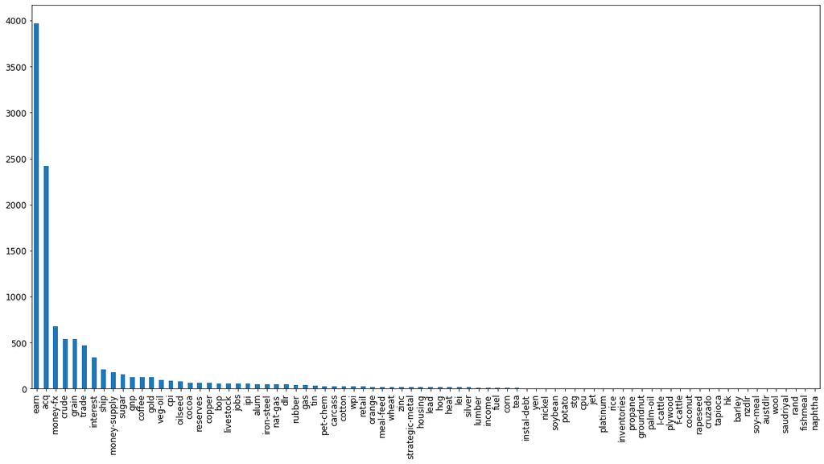

```python
from collections import Counter
import matplotlib.pyplot as plt

topic_counts = Counter(single_y_label)
#print(type(topic_counts))

df = pd.DataFrame.from_dict(topic_counts, orient='index')
print(type(df))
df.columns =['Counts']
df = df.sort_values(by=['Counts'], ascending = False)
print(df.head())

#newlist = y.index(['earn','acq'])
ax = df.plot(kind='bar', legend = None, figsize = (20,10), fontsize = 12)
```

## Non-negative Matrix Factorization

In thie section, we implement the non-negative matrix factorization method for topic modeling.

```python
from sklearn.decomposition import NMF

nmf_model = NMF(n_components = 20, random_state = 42)

nmf_model.fit(X)
```

```
NMF(n_components=20, random_state=42)
```

```python
list_topic_keywords = []
for index, topic in enumerate(nmf_model.components_):
    print(f'The top 15 words for topic # {index}')
    topic_keywords = [vectorizer.get_feature_names()[i] for i in topic.argsort()[-15:]]
    print(topic_keywords)
    list_topic_keywords.append(topic_keywords)
    print('\n')
```

```
The top 15 words for topic # 0
['gain', 'given', 'rev', 'ended', 'includes', 'seven', 'qtr', 'sales', 'note', 'mths', 'revs', 'net', 'shr', 'cts', 'vs']


The top 15 words for topic # 1
['previously', 'mthly', 'payable', 'qtrly', 'qtr', 'june', 'march', 'vs', 'april', 'prior', 'record', 'pay', 'qtly', 'div', 'cts']


The top 15 words for topic # 2
['exchange', 'securities', 'investment', 'share', 'pct', 'outstanding', 'stake', 'offer', 'group', 'stock', 'corp', 'common', 'company', 'said', 'shares']


The top 15 words for topic # 3
['losses', 'writedown', 'nil', 'dlr', 'operations', 'ct', 'shr', 'note', 'discontinued', 'net', 'year', 'includes', 'vs', 'revs', 'loss']


The top 15 words for topic # 4
['exports', 'reserves', 'marks', 'crowns', 'fell', 'dlrs', 'rose', 'assets', 'deficit', 'loans', 'deposits', 'vs', 'surplus', 'francs', 'billion']


The top 15 words for topic # 5
['year', 'making', 'dlr', 'debit', 'pre', 'note', 'mths', 'assets', 'turnover', 'net', 'extraordinary', 'tax', 'revs', 'vs', 'mln']


The top 15 words for topic # 6
['compares', 'estimate', 'provided', 'mln', 'revised', 'money', 'today', 'market', 'assistance', 'shortage', 'band', 'england', 'bills', 'bank', 'stg']


The top 15 words for topic # 7
['year', 'soviet', 'tender', 'season', 'tonne', 'agriculture', 'shipment', 'department', 'grain', 'corn', 'export', 'said', 'sugar', 'wheat', 'tonnes']


The top 15 words for topic # 8
['said', 'growth', 'inflation', 'fell', 'march', 'statistics', 'december', 'compared', 'index', 'rise', 'rose', 'year', 'january', 'february', 'pct']


The top 15 words for topic # 9
['market', 'nations', 'west', 'central', 'rates', 'baker', 'intervention', 'exchange', 'paris', 'dealers', 'japan', 'currency', 'said', 'yen', 'dollar']


```

[output cut: 23 more lines]

```

The top 15 words for topic # 16
['market', 'point', 'cut', 'effective', 'national', 'lending', 'central', 'prime', 'money', 'said', 'pct', 'banks', 'rates', 'rate', 'bank']


The top 15 words for topic # 17
['colombia', 'bags', 'international', 'meeting', 'buffer', 'prices', 'delegates', 'cocoa', 'export', 'producers', 'brazil', 'ico', 'said', 'quotas', 'coffee']


The top 15 words for topic # 18
['sale', 'expects', 'revenues', 'income', 'note', 'sales', 'company', 'gain', 'includes', 'earnings', 'net', 'year', 'share', 'quarter', 'dlrs']


The top 15 words for topic # 19
['market', 'said', 'government', 'trading', 'economists', 'securities', 'temporary', 'customer', 'agreements', 'repurchase', 'reserve', 'funds', 'reserves', 'federal', 'fed']
```

## Attaching Discoverd Topic Labels to the Original Articles

```python
corpus_df.head(10)
```

|  | Articles | Original Topic | Modeled Topic No. |
| --- | --- | --- | --- |
| 0 | showers continued throughout week bahia cocoa ... | [cocoa] | 18 |
| 1 | u agriculture department reported farmer owned... | [grain, wheat, corn, barley, oat, sorghum] | 7 |
| 2 | argentine grain board figures show crop regist... | [veg-oil, linseed, lin-oil, soy-oil, sun-oil, ... | 7 |
| 3 | champion products inc said board directors app... | [earn] | 11 |
| 4 | computer terminal systems inc said completed s... | [acq] | 2 |
| 5 | shr cts vs dlrs net vs assets mln vs mln depos... | [earn] | 5 |
| 6 | ohio mattress co said first quarter ending feb... | [earn, acq] | 18 |
| 7 | oper shr loss two cts vs profit seven cts oper... | [earn] | 10 |
| 8 | shr one dlr vs cts net mln vs mln revs mln vs ... | [earn] | 5 |
| 9 | dean foods co expects earnings fourth quarter ... | [earn] | 18 |

```
Counter({0: 1645, 2: 1628, 14: 899, 18: 824, 12: 793, 7: 687, 8: 608, 1: 517, 16: 500, 4: 447, 10: 368, 9: 363, 3: 351, 15: 308, 17: 302, 11: 269, 13: 241, 5: 218, 19: 202, 6: 197})
```

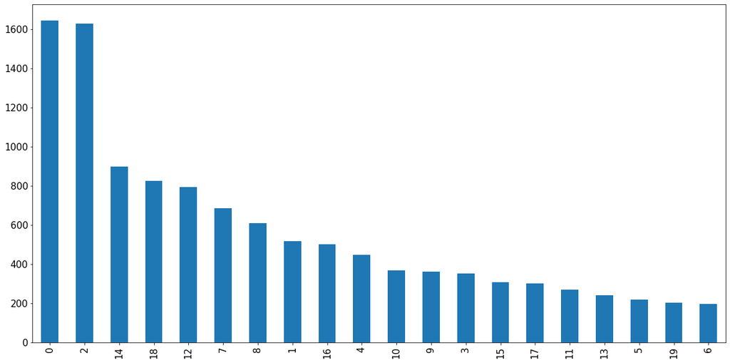

```python
topic_counts2 = Counter(corpus_df['Modeled Topic No.'])
print(topic_counts2)
df = pd.DataFrame.from_dict(topic_counts2, orient='index')

df = df.sort_values(by = [0],  ascending = False)

#newlist = y.index(['earn','acq'])
ax = df.plot(kind='bar', legend = None, figsize = (20,10), fontsize = 15)
```

```python
df.head

list_topic_df['Count'] = [df[0][i] for i in range(20)]
list_topic_df = list_topic_df.sort_values(by = 'Count',  ascending = False)
print(list_topic_df)
list_topic_df.to_csv('Modeled_top_lst&cnt.csv')
```

```
                                   Modeled Topic List  Count
0   [gain, given, rev, ended, includes, seven, qtr...   1645
2   [exchange, securities, investment, share, pct,...   1628
14  [day, texas, petroleum, energy, price, product...    899
18  [sale, expects, revenues, income, note, sales,...    824
12  [foreign, deficit, imports, countries, governm...    793
7   [year, soviet, tender, season, tonne, agricult...    687
8   [said, growth, inflation, fell, march, statist...    608
1   [previously, mthly, payable, qtrly, qtr, june,...    517
16  [market, point, cut, effective, national, lend...    500
4   [exports, reserves, marks, crowns, fell, dlrs,...    447
10  [turnover, parent, half, credit, extraordinary...    368
9   [market, nations, west, central, rates, baker,...    363
3   [losses, writedown, nil, dlr, operations, ct, ...    351
15  [periods, note, dlrs, ct, primary, mths, nil, ...    308
17  [colombia, bags, international, meeting, buffe...    302
11  [said, march, shareholders, cts, quarterly, ho...    269
13  [exclude, tax, year, share, extraordinary, net...    241
5   [year, making, dlr, debit, pre, note, mths, as...    218
19  [market, said, government, trading, economists...    202
6   [compares, estimate, provided, mln, revised, m...    197
```

# Classification using LSTM

In this section, we build a classification model using LSTM (Long short term memory). We only use the articles with top 5 frequent topics. Those topics are 'acq', 'crude', 'earn', 'grain' and 'money-fx'.

```python
corpus_df = pd.DataFrame({'Articles':corpus, 'Topic':single_y_label})

corpus_df = (corpus_df.loc[corpus_df['Topic'].isin(['acq','crude','earn','grain', 'money-fx'])])

print(corpus_df.iloc[1][0])
```

```
champion products inc said board directors approved two one stock split common shares shareholders record april company also said board voted recommend shareholders annual meeting april increase authorized capital stock five mln mln shares
```

```python
from sklearn.preprocessing import OneHotEncoder
from sklearn.preprocessing import LabelEncoder
from sklearn.model_selection import train_test_split
from sklearn.metrics import confusion_matrix

from keras.preprocessing import sequence
from keras.preprocessing.text import Tokenizer
from keras.models import Sequential
from keras.layers import Dense, LSTM
from keras.layers.embeddings import Embedding
```

```python
tokenizer = Tokenizer()

tokenizer.fit_on_texts(corpus_df['Articles'])
```

```python
import numpy as np

encoded_texts = corpus_df['Articles'].to_numpy()
encoded_texts = tokenizer.texts_to_sequences(encoded_texts)
```

```python
encoded_texts = sequence.pad_sequences(encoded_texts, maxlen = 500)
```

```python
y_labels = corpus_df['Topic']
le = LabelEncoder()
y_labels_le = le.fit_transform(y_labels)
print(np.array(y_labels_le))
```

```
[3 2 0 ... 3 0 4]
```

```python
y_labels_le = y_labels_le[:, np.newaxis]

one_hot_encoder = OneHotEncoder(sparse = False)
y_labels_encoded = one_hot_encoder.fit_transform(y_labels_le)
```

```python
y_labels_encoded
```

```
array([[0., 0., 0., 1., 0.],
       [0., 0., 1., 0., 0.],
       [1., 0., 0., 0., 0.],
       ...,
       [0., 0., 0., 1., 0.],
       [1., 0., 0., 0., 0.],
       [0., 0., 0., 0., 1.]])
```

# Model Training

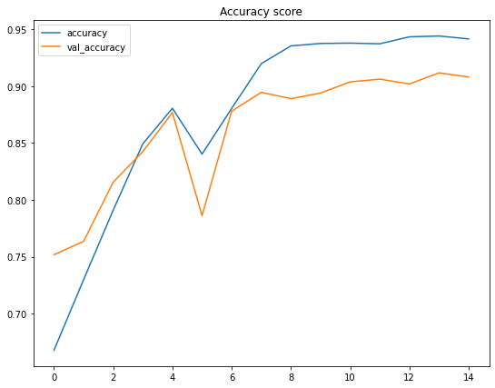

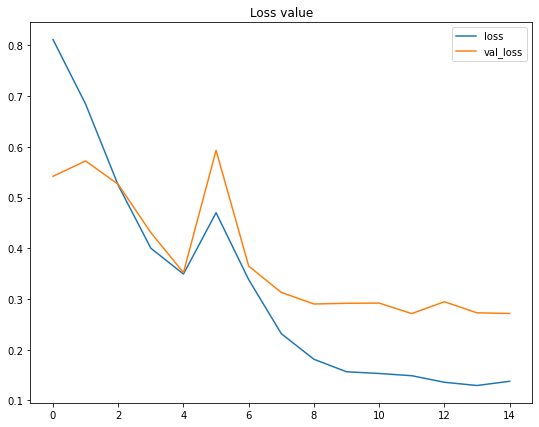

```python
X_train, X_test, y_train, y_test = train_test_split(encoded_texts, y_labels_encoded,test_size=0.2, random_state=11)

# Construct the neural network
model = Sequential()
model.add(Embedding(input_dim=19925, output_dim=32, input_length=500))
model.add(LSTM(100))
model.add(Dense(5, activation='sigmoid'))

model.compile(loss='categorical_crossentropy',
              optimizer='adam',
              metrics=['accuracy'])

# Train the model
history = model.fit(X_train, y_train, epochs=15, batch_size=32, validation_data=(X_test, y_test))

# Save the model for future use
model.save('news_topic_classification_lstm_model.h5')

# Display the training process
plt.figure(figsize=(9,7))
plt.title('Accuracy score')
plt.plot(history.history['accuracy'])
plt.plot(history.history['val_accuracy'])
plt.legend(['accuracy', 'val_accuracy'])
plt.show()

plt.figure(figsize=(9,7))
plt.title('Loss value')
plt.plot(history.history['loss'])
plt.plot(history.history['val_loss'])
plt.legend(['loss', 'val_loss'])
plt.show()
```

# Model Evaluation

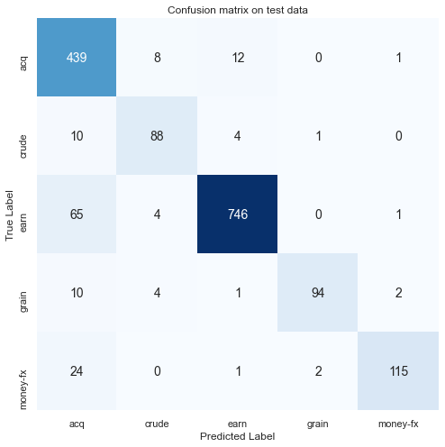

```python
import seaborn as sns; sns.set()

# Predict test data
predictions = model.predict(X_test)
predictions = one_hot_encoder.inverse_transform(predictions)

# Convert y_test (actual label) from one-hot format
# to be in the same form of predictions array
y_test_evaluate = np.argmax(y_test, axis=1)

# Construct a confusion matrix
cm = confusion_matrix(y_test_evaluate, predictions)

labels = ['acq','crude','earn','grain', 'money-fx']

# Display the confusion matrix
plt.figure(figsize=(8,8))
plt.title('Confusion matrix on test data')
sns.heatmap(cm, annot=True, fmt='d', xticklabels=labels, yticklabels=labels,
            cmap=plt.cm.Blues, cbar=False, annot_kws={'size':14})
plt.xlabel('Predicted Label')
plt.ylabel('True Label')
plt.show()
```